# AN(C)OVA in R

## Introduction

In ANOVA, the goal is to compare means of an outcome variable between groups when we have more than 2 groups. We do not test between which groups the differences are but rather if there is a difference at all. We could test which group means differ by using posthoc tests when using the frequentist approach (more on that later). This article assumes that you have background knowledge in linear models, especially fitting linear regression models in R. ANOVA and also ANCOVA can be described as special cases of a linear regression model, where e.g. a one way ANOVA is simply a linear regression with a categorical predictor. I want to acknowledge the authors of F. Korner-Nievergelt et al. (2015) because for this article I use in part their code examples, especially when it comes to the simulation of data and the intro to the Bayesian framework when it comes to ANOVA. I will also rely on principles that have been formulated by Gelman & Hill (2007).

## Behind the scenes

To explain the procedure, I will compare it with what we are used to when fitting a linear regression model: In linear regression, we compare whether the linear model that we use to create the regression line, fits the data better than the baseline model (mean). The fit is reflected by the variance around the mean and the regression line, respectively.

#### SST, SSW and SSB

The variance of the data around our basic model (mean) is called the *total sum of squares* and is defined as:

$$SST = \sum_{i=1}^n (y_i-\bar{y})^2$$

The variance of the data around the ‘better’ model or stated differently: The variance that the better model still cannot explain, is the *residual sum of squares* and is defined as:

$$RSS = \sum_{i=1}^n (y_i - \hat{y}_i)^2$$

In the context of ANOVA, this is often referred to as *sum of squares within* (SSW). As in ANOVA the model is the corresponding group mean, we can write more specifically:

$$SSW=\sum_{i=1}^n(y_i-\bar{y}_{gi})^2$$

If we subtract RSS from SST, we end up with the *model sum of squares*. In the context of ANOVA, the term is called *sum of squares between* (SSB):

$$SSB=\sum_{i=1}^n(\bar{y_{gi}}-\bar{y})^2$$

SSM/SSB reflect the part of the SST that the ‘better’ model can explain, whereas RSS/SSW reflect the part of the SST that the ‘better’ model still cannot explain. In summary: SSB+SSW=SST.

#### Frequentist approach

Our null hypothesis is that $\theta_1 = \theta_2 = \theta_3$. If this hypothesis is true, we expect that the variance between the groups equals the variance within the groups. We calculate the mean sum of squares (MSB and MSW) by dividing SSB and SSW by their corresponding degrees of freedom, which are $df_{SSB}=k-1$ and $df_{SSW} = N-k$. Then we can calculate the F-statistic:

$$F=\frac{MSB}{MSW}$$

Depending of the degrees of freedom ($df_{SSB}$ and $df_{SSW}$), we can check the distribution of the F-value under $H_0$ to check for the probability that we get the F-value we have or a more extreme one. At the cutoff of 0.05, we would decide that there is a least one mean that is different from the other means.

## One-Way ANOVA in R

If we fit a linear model, R automatically picks $\beta_0$ as the reference group. Thus, the intercept reflects the group mean of the first group. If we have three groups, then $\beta_1$ reflects the difference in means between the first and the second group and $\beta_2$ relfects the difference in means between the first and the third group. I will simulate data (3 groups with different means) and then illustrate this using lm in R:

```r
#import libraries needed
library(arm)
```

```r
library(ggplot2)
library(reshape2)
library(plyr)
#simulate data
b0 <- 12 #true mean group 1
b1 <- 0.75 #difference in true means between group 2 to group 1
b2 <- -0.75 #difference in true means between group 1 and group 3
sigma <- 2 #residual SD (=within group SD)
n <- 90
group <- factor(rep(c(1, 2, 3), each=30))
#simulate the y variable
simresid <- rnorm(n, mean=0, sd=sigma)
y <- b0 + as.numeric(group=='2') *b1 + as.numeric(group=='3')*b2 + simresid
df <- data.frame(group, y)
#The means of the fake data
ddply(df, .(group), summarize, mean = mean(y))
```

| group | mean |
| --- | --- |
| 1 | 11.56759 |
| 2 | 12.65136 |
| 3 | 11.70593 |

```r
#fit linear model
mod <- lm('y~group', df)
coefs <- coef(mod)
summary(mod)
```

```
##
## Call:
## lm(formula = "y~group", data = df)
##
## Residuals:
##     Min      1Q  Median      3Q     Max
## -4.9679 -1.2296  0.2302  1.4510  3.3244
##
## Coefficients:
##             Estimate Std. Error t value Pr(>|t|)
## (Intercept)  11.5676     0.3455  33.478   <2e-16 ***
## group2        1.0838     0.4887   2.218   0.0292 *
## group3        0.1383     0.4887   0.283   0.7778
## ---
## Signif. codes:  0 '***' 0.001 '**' 0.01 '*' 0.05 '.' 0.1 ' ' 1
##
## Residual standard error: 1.893 on 87 degrees of freedom
## Multiple R-squared:  0.06279,    Adjusted R-squared:  0.04124
## F-statistic: 2.914 on 2 and 87 DF,  p-value: 0.05956
```

```r
#see how aov yields the same F-test for one-way A
aovmod <- aov(y~group, df)
summary(aovmod)
```

```
##             Df Sum Sq Mean Sq F value Pr(>F)
## group        2  20.88  10.438   2.914 0.0596 .
## Residuals   87 311.61   3.582
## ---
## Signif. codes:  0 '***' 0.001 '**' 0.01 '*' 0.05 '.' 0.1 ' ' 1
```

#### A Bayesian way

Using the Bayesian framework we could ask in how far the data support the hypothesis that the mean of group 2 or group 3 is greater than mean of group 1. We could simulate the posterior distribution of the parameters and their differences. Then we could calculate the 95% credible intervals (CrI) to give an estimate. Here is how such a simulation could look like using the *arm* package. I used different parameters for the fake data simulation to get a feeling for these tools:

```r
bsim <- sim(mod, n.sim=1000)
m.g1 <- coef(bsim)[,1]
m.g2 <- coef(bsim)[,1] + coef(bsim)[,2]
m.g3 <- coef(bsim)[,1]+ coef(bsim)[,3]
df <- data.frame(m.g1,m.g2,m.g3)
dfl <- melt(df)
head(df)
```

|  | m.g1 | m.g2 | m.g3 |
| --- | --- | --- | --- |
| 1 | 11.43533 | 12.94229 | 12.00180 |
| 2 | 11.24799 | 12.49296 | 11.87682 |
| 3 | 11.28875 | 12.33059 | 11.18574 |
| 4 | 11.37093 | 12.24119 | 11.37153 |
| 5 | 11.80065 | 12.29142 | 11.56649 |
| 6 | 11.96024 | 12.59930 | 11.68627 |

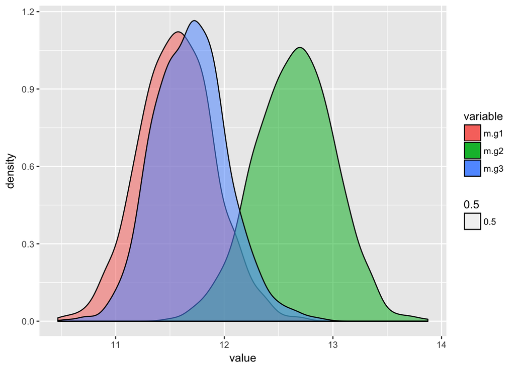

```r
#Posterior distribution of group means
qplot(value, data=dfl, alpha = 0.5, geom='density', fill=variable)
```

```r
#difference between group 2 and 1
d.g1.2 <- df$m.g1-df$m.g2
mean(d.g1.2)
```

```
## [1] -1.084901
```

```r
quantile(d.g1.2, prob=c(0.025,0.975))
```

```
##        2.5%       97.5%
## -1.99236893 -0.09602237
```

```r
#difference between group 3 and 1
d.g1.3 <- df$m.g1-df$m.g3
mean(d.g1.3)
```

```
## [1] -0.1269724
```

```r
quantile(d.g1.3, prob=c(0.025,0.975))
```

```
##       2.5%      97.5%
## -1.1020129  0.7778338
```

```r
#how strongly do the data support that means group 2 > group 1?
mean(m.g3>m.g1)
```

```
## [1] 0.609
```

## Two-Way ANOVA

For this part I use the dataset out of the book (F. Korner-Nievergelt et al., 2015). Let us have a look at the columns. It is self-explanatory:

```r
library(blmeco)
data(periparusater)
df <- periparusater
summary(df)
```

```
##         country   age    sex        weight             P8
##  Algeria    : 1   3: 6   1:12   Min.   : 8.000   Min.   :46.00
##  Bulgaria   : 2   4:13   2: 7   1st Qu.: 8.950   1st Qu.:48.25
##  Russia     : 2                 Median : 9.500   Median :49.50
##  Switzerland:14                 Mean   : 9.447   Mean   :49.24
##                                 3rd Qu.: 9.900   3rd Qu.:50.00
##                                 Max.   :11.000   Max.   :52.50
##       wing
##  Min.   :57.00
##  1st Qu.:61.50
##  Median :63.50
##  Mean   :63.21
##  3rd Qu.:64.50
##  Max.   :69.00
```

```r
head(df)
```

|  | country | age | sex | weight | P8 | wing |
| --- | --- | --- | --- | --- | --- | --- |
| 3 | Russia | 3 | 2 | 9.4 | 46.0 | 59.5 |
| 4 | Russia | 4 | 1 | 8.9 | 48.5 | 63.5 |
| 8 | Switzerland | 4 | 1 | 9.5 | 50.0 | 64.0 |
| 10 | Switzerland | 4 | 2 | 8.0 | 47.0 | 61.0 |
| 11 | Switzerland | 4 | 1 | 9.5 | 50.5 | 66.0 |
| 12 | Switzerland | 4 | 1 | 11.0 | 50.0 | 64.5 |

We will compare the wing length of *Periparus ater* between the two age groups (juvenile vs adult) and the two sexes:

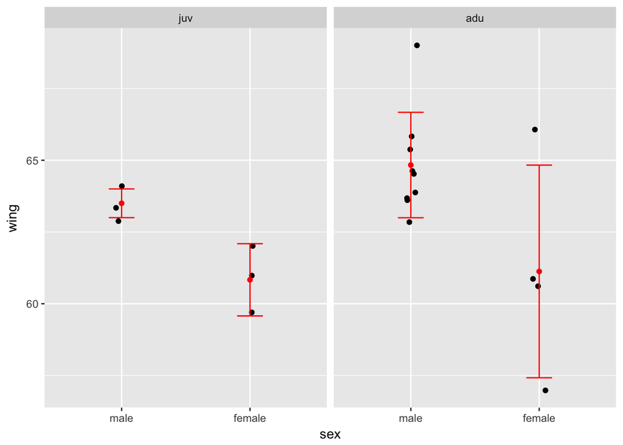

```r
#change names for convenience
levels(df$age) = c('juv', 'adu')
levels(df$sex) = c('male', 'female')
#fit model
pmod <- lm('wing ~ sex + age', df)
#plot means and individuals data points
ggplot(df, aes(x=sex,y=wing)) +
  geom_jitter(width=0.05) +
  stat_summary(fun.y = mean, geom = 'point', color = 'red') +
  stat_summary(fun.data = mean_sdl, fun.args = list(mult = 1), geom = "errorbar", width = 0.2, col='red') +
  facet_grid(.~age)
```

```r
summary(pmod)
```

```
##
## Call:
## lm(formula = "wing ~ sex + age", data = df)
##
## Residuals:
##     Min      1Q  Median      3Q     Max
## -4.3784 -0.9369 -0.3378  0.6419  4.6216
##
## Coefficients:
##             Estimate Std. Error t value Pr(>|t|)
## (Intercept)  63.8378     1.0131  63.014  < 2e-16 ***
## sexfemale    -3.3423     1.0331  -3.235  0.00518 **
## ageadu        0.8829     1.0721   0.823  0.42234
## ---
## Signif. codes:  0 '***' 0.001 '**' 0.01 '*' 0.05 '.' 0.1 ' ' 1
##
## Residual standard error: 2.135 on 16 degrees of freedom
## Multiple R-squared:  0.4398, Adjusted R-squared:  0.3698
## F-statistic: 6.282 on 2 and 16 DF,  p-value: 0.009695
```

We have the following model:

$$wing = 63.84 - 3.34female + 0.88adu$$

This model would translate to: The mean wing length of male juvenile birds is 63.84 and female wings are 3.35 shorter given that they belong to the same agegroup. Adult wing length is 0.88 longer than juvenile length, given that we compare birds from the same sex. However, as we already could see in the plot, the difference between juvenile and adult is different depending on sex. Let us see what happens if we include the interaction $sex \times age$:

```r
pmod2 <- lm('wing ~ sex * age', df)
summary(pmod2)
```

```
##
## Call:
## lm(formula = "wing ~ sex * age", data = df)
##
## Residuals:
##     Min      1Q  Median      3Q     Max
## -4.1250 -1.0833 -0.3333  0.5833  4.8750
##
## Coefficients:
##                  Estimate Std. Error t value Pr(>|t|)
## (Intercept)        63.500      1.264  50.252   <2e-16 ***
## sexfemale          -2.667      1.787  -1.492    0.156
## ageadu              1.333      1.459   0.914    0.375
## sexfemale:ageadu   -1.042      2.219  -0.469    0.645
## ---
## Signif. codes:  0 '***' 0.001 '**' 0.01 '*' 0.05 '.' 0.1 ' ' 1
##
## Residual standard error: 2.189 on 15 degrees of freedom
## Multiple R-squared:  0.4479, Adjusted R-squared:  0.3375
## F-statistic: 4.057 on 3 and 15 DF,  p-value: 0.02692
```

```r
amod <- aov(wing ~ sex * age, df)
summary(amod)
```

```
##             Df Sum Sq Mean Sq F value  Pr(>F)
## sex          1  54.16   54.16  11.306 0.00428 **
## age          1   3.09    3.09   0.645 0.43442
## sex:age      1   1.06    1.06   0.220 0.64549
## Residuals   15  71.85    4.79
## ---
## Signif. codes:  0 '***' 0.001 '**' 0.01 '*' 0.05 '.' 0.1 ' ' 1
```

$$wing=63.5 -2.67female + 1.33adu -1.04fem \times adu$$

First the function *aov* tests whether *sex* explains a significant amount of variance over the baseline model. Then it checks whether *age* explains significant amount of variance when added to the model where *sex* is already implemented and so forth… Another method would be marginal F-tests, which tests whether any of the variables explains a significant amount of variance when all other variables are already in the model. It is important to know that the order in which we enter the variables in the function determines in which order the sequential analysis works. In case, the F-test yields a significant result, post hoc test could be conducted to further analyze which group means differ. In the Bayesian framework we have a 5% chance that the true value lies outside the credible interval (CrI) every time we calculate it, so there is also a similar problem. Personally, I will stick with the following advice given by Gelman & Hill (2007):

> - Formulate scientific hypotheses prior to data collection and stick to these during data analyses
> - Use, whenever possible hierarchical models (mixed models)
> - Accept that the true parameter value is outside the 95% CrI in 5% of the cases
> - Be honest - that is, describe the search effort that has been spent to find significant results, and also publish the nonsignificant results

## ANCOVA

ANCOVA tries to answer questions like: ‘Are there differences between means of the groups after adjusting for a covariate?’. Field (2012) explains that the covariate is a continuous variable that is thought to reduce the RSS of the model, thereby increasing the power of the F-test. However, we also have one df less for each covariate that we include in the model. Therefore, including covariates in the model always comes at a trade-off. Tabachnick & Fidell (2007) notes that the interpretation of *adjusted mean* is misleading because it may not correspond to any real life situation: Adjusted means would mean that all subjects had the same score on the covariate. That is not realistic, especially in non-experimental settings. So they conclude:  
> At best, the nonexperimental use of ANCOVA allows you to look at IV-DV relationships adjusted for the effects of CVs.

F. Korner-Nievergelt et al. (2015) give an example where the (log) biomass of two grass species is compared, while taking into consideration the average distance to ground water. However, they do not invest a lot into this model within the context of ANCOVA since they will analyze the same data in a mixed model design later.

```r
data(ellenberg)
df <- ellenberg[is.element(ellenberg$Species, c('Ap', 'Dg')),]
df <- droplevels(df)
str(df)
```

```
## 'data.frame':    88 obs. of  29 variables:
##  $ Year        : int  1952 1952 1952 1952 1952 1952 1952 1952 1952 1952 ...
##  $ Soil        : Factor w/ 2 levels "Loam","Sand": 1 1 1 1 1 1 1 1 1 1 ...
##  $ Water       : int  -5 5 20 35 50 65 80 95 110 125 ...
##  $ Species     : Factor w/ 2 levels "Ap","Dg": 1 1 1 1 1 1 1 1 1 1 ...
##  $ Mi.g        : num  NA 112.6 66.1 42.3 38.4 ...
##  $ Yi.g        : num  NA 34.8 28 44.5 24.8 ...
##  $ Mono.area.m2: num  NA 0.383 0.383 0.383 0.383 0.383 0.383 0.383 0.383 0.383 ...
##  $ Mix.area.m2 : num  NA 1.2 1.2 1.2 1.2 1.2 1.2 1.2 1.2 1.2 ...
##  $ Div         : int  NA 6 6 6 6 6 6 6 6 6 ...
##  $ Moi.g.m2    : num  NA 294 173 110 100 ...
##  $ Yoi.g.m2    : num  NA 29 23.3 37.1 20.6 ...
##  $ Mo.g.m2     : num  NA 377 356 281 208 ...
##  $ Yo.g.m2     : num  NA 229 291 299 314 ...
##  $ RYoi        : num  NA 0.0985 0.1352 0.3357 0.2057 ...
##  $ RYo         : num  NA 0.67 0.697 1.049 1.011 ...
##  $ Yei.g.m2    : num  NA 49 28.8 18.4 16.7 ...
##  $ Ye.g.m2     : num  NA 377 356 281 208 ...
##  $ RRYo        : num  NA 0.147 0.194 0.32 0.204 ...
##  $ deltaRYoi   : num  NA -0.04854 -0.05873 0.01577 0.00219 ...
##  $ deltaRYo    : num  NA -0.05501 -0.05046 0.00821 0.0018 ...
##  $ RYe         : num  NA 0.167 0.167 0.167 0.167 ...
##  $ deltaRYe    : num  NA -0.0196 0.0273 0.1532 0.0369 ...
##  $ RYT         : num  NA 0.67 0.697 1.049 1.011 ...
##  $ level       : Factor w/ 1 level "species": 1 1 1 1 1 1 1 1 1 1 ...
##  $ NE          : num  NA NA NA NA NA NA NA NA NA NA ...
##  $ TICE        : num  NA NA NA NA NA NA NA NA NA NA ...
##  $ SE          : num  NA NA NA NA NA NA NA NA NA NA ...
##  $ TDCE        : num  NA NA NA NA NA NA NA NA NA NA ...
##  $ DE          : num  NA NA NA NA NA NA NA NA NA NA ...
```

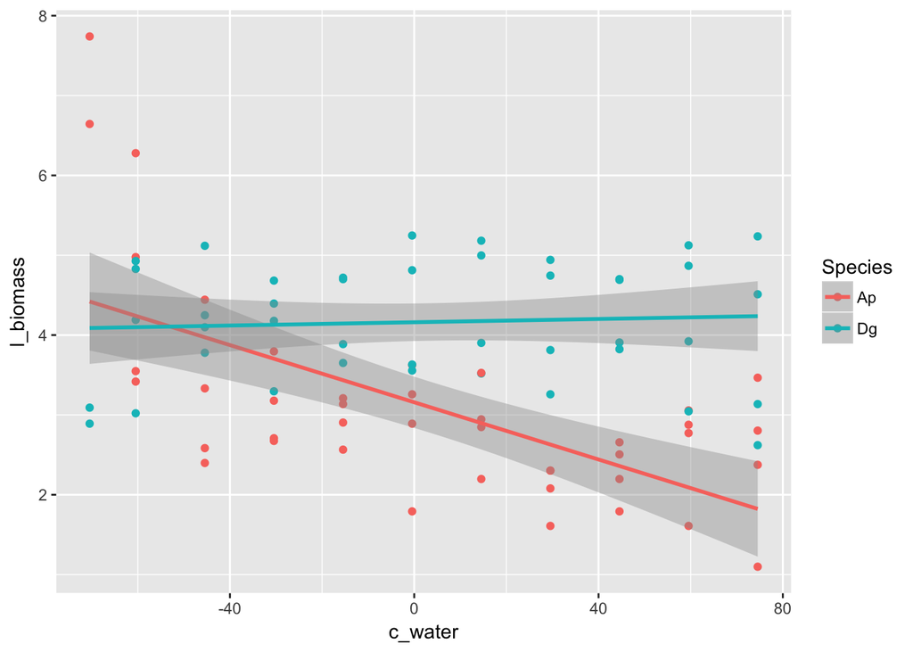

```r
#center cov
df$c_water <- scale(df$Water, center=T, scale=F)
df$l_biomass <- log(df$Yi.g)
ggplot(df, aes(x=c_water, y=l_biomass, color=Species)) +
geom_point() +
geom_smooth(method='lm')
```

```r
mod <- lm(l_biomass ~Species * c_water, data=df)
summary(mod)
```

```
##
## Call:
## lm(formula = l_biomass ~ Species * c_water, data = df)
##
## Residuals:
##     Min      1Q  Median      3Q     Max
## -1.6158 -0.6135 -0.1063  0.5876  3.3203
##
## Coefficients:
##                    Estimate Std. Error t value Pr(>|t|)
## (Intercept)        3.158048   0.139280  22.674  < 2e-16 ***
## SpeciesDg          1.002414   0.196971   5.089 2.33e-06 ***
## c_water           -0.017911   0.003075  -5.825 1.15e-07 ***
## SpeciesDg:c_water  0.018935   0.004349   4.354 3.92e-05 ***
## ---
## Signif. codes:  0 '***' 0.001 '**' 0.01 '*' 0.05 '.' 0.1 ' ' 1
##
## Residual standard error: 0.9002 on 80 degrees of freedom
##   (4 observations deleted due to missingness)
## Multiple R-squared:  0.4425, Adjusted R-squared:  0.4215
## F-statistic: 21.16 on 3 and 80 DF,  p-value: 3.454e-10
```

```r
head(model.matrix(mod))
```

```
##    (Intercept) SpeciesDg     c_water SpeciesDg:c_water
## 24           1         0 -60.4545455                 0
## 25           1         0 -45.4545455                 0
## 26           1         0 -30.4545455                 0
## 27           1         0 -15.4545455                 0
## 28           1         0  -0.4545455                 0
## 29           1         0  14.5454545                 0
```

A useful question in ecology that we could try to answer with this model is at which water level species Dg will outperform Ap. This is at the crosspoint in the above graph.

## Lecture

#### Planned contrast

We can specify beforehand that we are only interested in testing the group differences between certain groups and leave out others.

```r
#1. Test assumptions
#Independence of residuals
#homogeneity of Variance between groups
#normal distributions within groups

#2. specify contrasts
#3. perform analysis
#4. check models diagnostics
#5. Examine results
```

## Notes for contrasts in R:

- there are only k-1 orthogonal comparisons (where k is the number of factor levels)
- that means these are statistical independent
- choose contrasts based on your hypothesis before data collection

## References

Field, A. (2012). *Discovering Statistics Using R*. SAGE Publications Ltd.

Gelman, A., & Hill, J. (2007). *Data Analysis using Regression and Multilevel/Hierarchical Models* (p. 651). https://doi.org/10.2277/0521867061

Korner-Nievergelt, F., Roth, T., Felten, S. von, Guélat, J., Almasi, B., & Korner-Nievergelt, P. (2015). Chapter 4 - normal linear models. In F. Korner-Nievergelt, T. Roth, S. von Felten, J. Guélat, B. Almasi, & P. Korner-Nievergelt (Eds.), *Bayesian data analysis in ecology using linear models with r, bugs, and {stan}* (pp. 33–68). Boston: Academic Press. https://doi.org/https://doi.org/10.1016/B978-0-12-801370-0.00004-6

Tabachnick, B. G., & Fidell, L. S. (2007). *Using multivariate statistics* (5th ed., p. 980). Boston: Pearson Education.